# Linear Regression Lecture Demo

These problems are some of the issues associated with *extrapolation*.

Extrapolation occurs when you try to use an estimated regression equation to predict a new y value for x values outside of the range of of the sample data used to determine the regression equation.

Another extrapolation example… from the Anscombe dataset you saw before:

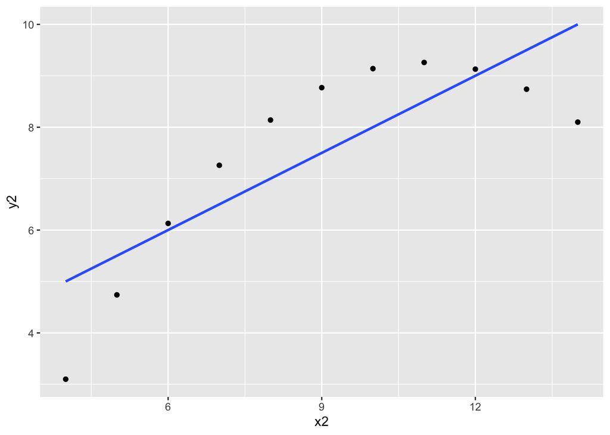

```r
ggplot(anscombe, aes(x=x2, y=y2)) +
  geom_point() + geom_smooth(method = "lm", se = FALSE)
```

```r
summary(mod2)
```

```
##
## Call:
## lm(formula = y2 ~ x2, data = anscombe)
##
## Residuals:
##     Min      1Q  Median      3Q     Max
## -1.9009 -0.7609  0.1291  0.9491  1.2691
##
## Coefficients:
##             Estimate Std. Error t value Pr(>|t|)
## (Intercept)    3.001      1.125   2.667  0.02576 *
## x2             0.500      0.118   4.239  0.00218 **
## ---
## Signif. codes:  0 '***' 0.001 '**' 0.01 '*' 0.05 '.' 0.1 ' ' 1
##
## Residual standard error: 1.237 on 9 degrees of freedom
## Multiple R-squared:  0.6662, Adjusted R-squared:  0.6292
## F-statistic: 17.97 on 1 and 9 DF,  p-value: 0.002179
```

Predict a value for x = 20:

```r
3+.5*20
```

```
## [1] 13
```

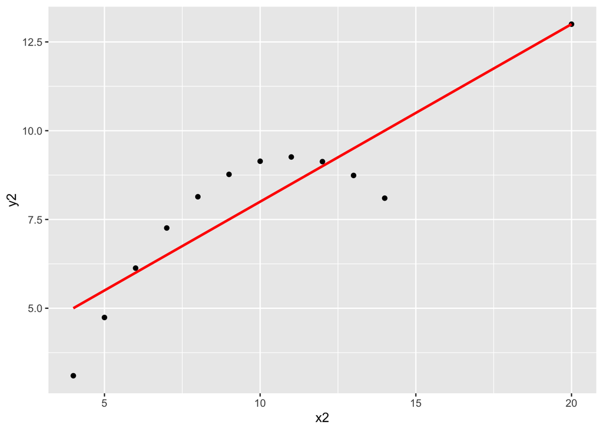

```r
newanscombe=data.frame(x2=20, y2=13)

ggplot(anscombe, aes(x=x2, y=y2)) +
  geom_point() + geom_point(data = newanscombe) +
  geom_smooth(method = "lm", se = FALSE, fullrange = T, color = "red")
```

Probably not right… more likely to be something like:

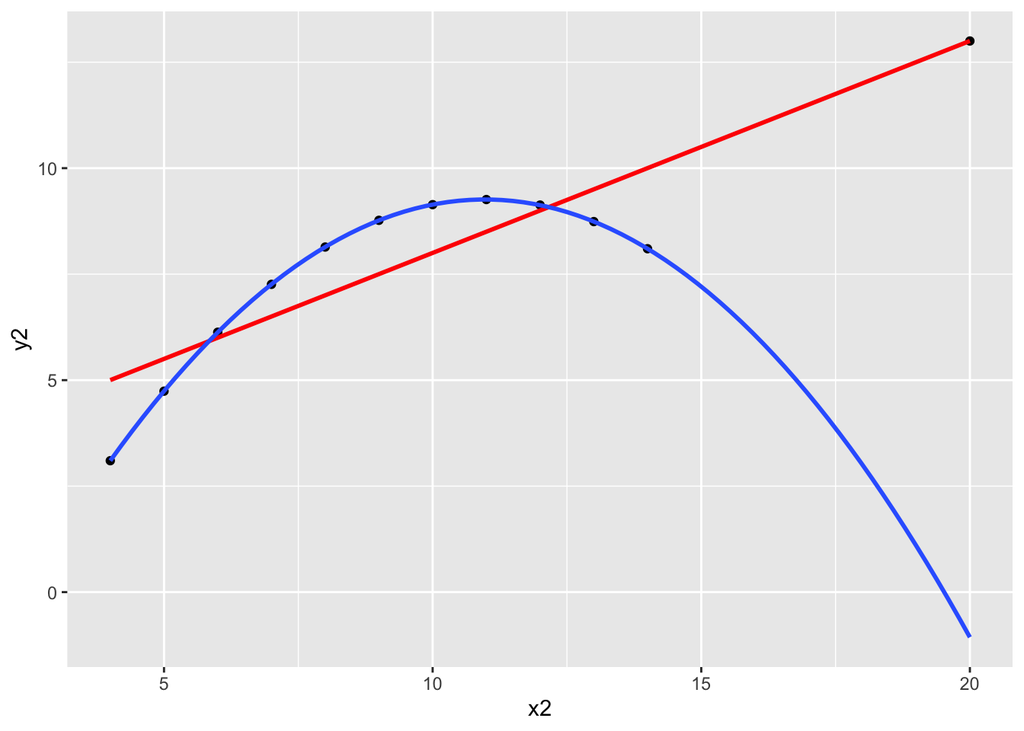

```r
ggplot(anscombe, aes(x=x2, y=y2)) +
  geom_point() + geom_point(data = newanscombe) +
  geom_smooth(method = "lm", se = FALSE, fullrange = T,  color = "red") +
  geom_smooth(method = "lm", formula= y ~ poly(x, 2, raw=TRUE), se = FALSE, fullrange = T)
```

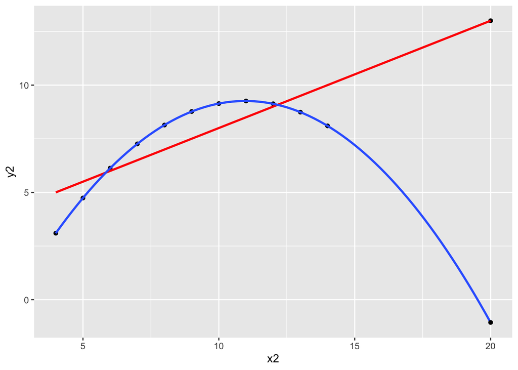

```r
quadanscombe=data.frame(x2=20, y2=-1.0598)

ggplot(anscombe, aes(x=x2, y=y2)) +
  geom_point() + geom_point(data = newanscombe) +
  geom_smooth(method = "lm", se = FALSE, fullrange = T,  color = "red") +
  geom_smooth(method = "lm", formula= y ~ poly(x, 2, raw=TRUE), se = FALSE, fullrange = T) +
  geom_point(data = quadanscombe)
```

Very very different predictions for x=20!! Linear regression is not always the answer. How could we have known that the linear model was not appropriate, before even trying to extrapolate?

Residual plot!!!

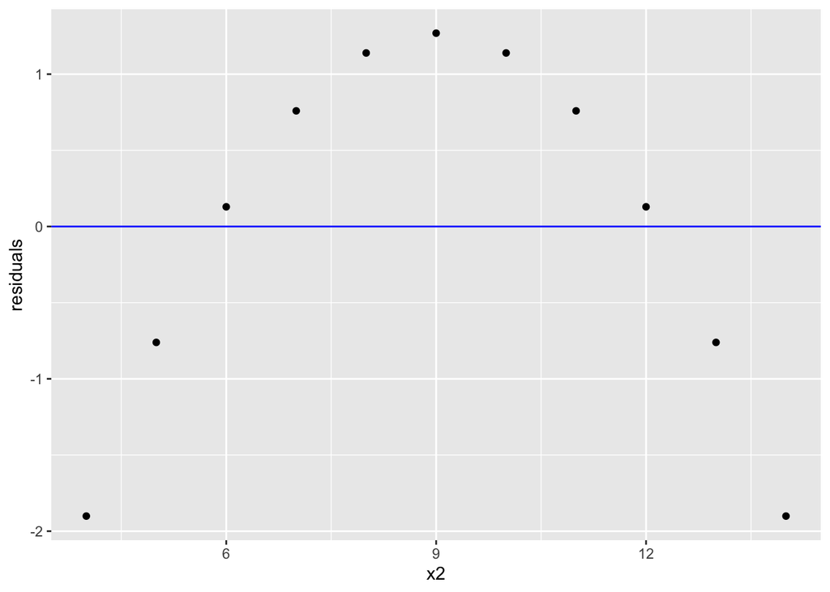

```r
anscombedata=anscombe
ansline=lm(y2~x2, data=anscombedata)
anscombedata$residuals=residuals(ansline)

ggplot(anscombedata, aes(x=x2, y=residuals))  +
  geom_hline(aes(yintercept = 0), color="blue") +
  geom_point()
```

Clear pattern! Systematic error is present in the LSRL predictions.

Btw if you were wondering how I got that point, (20, -1.0598), I used polynomial regression– a more advanced generalization of linear regression:

```r
lm(y2 ~ poly(x2, 2, raw=TRUE), data=anscombe)
```

```
##
## Call:
## lm(formula = y2 ~ poly(x2, 2, raw = TRUE), data = anscombe)
##
## Coefficients:
##              (Intercept)  poly(x2, 2, raw = TRUE)1  poly(x2, 2, raw = TRUE)2
##                  -5.9957                    2.7808                   -0.1267
```

```r
-5.9958+2.7808*20-0.1267*(20)^2
```

```
## [1] -1.0598
```

Bonus video: This is what might happen to you if you try to extrapolate. :P  
https://vimeo.com/212731897 ```